# Regressão Linear - Projeto

Parabéns! Você obteve algum contrato de trabalho com uma empresa de comércio eletrônico com sede na cidade de Nova York que vende roupas online, mas também tem sessões de consultoria em estilo e vestuário na loja. Os clientes entram na loja, têm sessões / reuniões com um estilista pessoal, então podem ir para casa e encomendarem em um aplicativo móvel ou site para a roupa que desejam.

A empresa está tentando decidir se deve concentrar seus esforços em sua experiência em aplicativos móveis ou em seu site. Eles contrataram você no contrato para ajudá-los a descobrir isso! Vamos começar!

Basta seguir as etapas abaixo para analisar os dados do cliente (é falso, não se preocupe, eu não lhe dei números reais de cartões de crédito ou e-mails).

## Imports

** Importe pandas, numpy, matplotlib,e seaborn. Em seguida, configure% matplotlib inline (Você importará sklearn conforme você precisar). **

```python
# prompt: Importe pandas, numpy, matplotlib,e seaborn. Em seguida, configure% matplotlib inline

import pandas as pd
import numpy as np
import matplotlib.pyplot as plt
import seaborn as sns
%matplotlib inline
```

## Obter dados

Trabalharemos com o arquivo csv do Ecommerce Customers da empresa. Possui informações do cliente, como Email, Endereço e sua cor Avatar. Em seguida, ele também possui colunas de valores numéricos:.

- Avg. Session Length: Tempo médio das sessões de consultoria de estilo na loja.
- Time on App: tempo médio gasto no app em minutos.
- Time on Website: tempo médio gasto no site em minutos.
- Lenght of Membership: Há quantos anos o cliente é membro.

** Leia no arquivo csv do Ecommerce Customers como um DataFrame chamado clientes. **

```python
dados = pd.read_csv('EcommerceCustomers.csv', index_col=0)
```

** Verifique o cabeçalho dos clientes e confira os seus métodos info () e describe(). **

```python
dados.head()
```

| Email | Address | Avatar | Avg. Session Length | Time on App | Time on Website | Length of Membership | Yearly Amount Spent |
| --- | --- | --- | --- | --- | --- | --- | --- |
| mstephenson@fernandez.com | 835 Frank Tunnel\nWrightmouth, MI 82180-9605 | Violet | 34.497268 | 12.655651 | 39.577668 | 4.082621 | 587.951054 |
| hduke@hotmail.com | 4547 Archer Common\nDiazchester, CA 06566-8576 | DarkGreen | 31.926272 | 11.109461 | 37.268959 | 2.664034 | 392.204933 |
| pallen@yahoo.com | 24645 Valerie Unions Suite 582\nCobbborough, D... | Bisque | 33.000915 | 11.330278 | 37.110597 | 4.104543 | 487.547505 |
| riverarebecca@gmail.com | 1414 David Throughway\nPort Jason, OH 22070-1220 | SaddleBrown | 34.305557 | 13.717514 | 36.721283 | 3.120179 | 581.852344 |
| mstephens@davidson-herman.com | 14023 Rodriguez Passage\nPort Jacobville, PR 3... | MediumAquaMarine | 33.330673 | 12.795189 | 37.536653 | 4.446308 | 599.406092 |

```python
dados.info()
```

```
<class 'pandas.core.frame.DataFrame'>
Index: 500 entries, mstephenson@fernandez.com to hannahwilson@davidson.com
Data columns (total 7 columns):
 #   Column                Non-Null Count  Dtype
---  ------                --------------  -----
 0   Address               500 non-null    object
 1   Avatar                500 non-null    object
 2   Avg. Session Length   500 non-null    float64
 3   Time on App           500 non-null    float64
 4   Time on Website       500 non-null    float64
 5   Length of Membership  500 non-null    float64
 6   Yearly Amount Spent   500 non-null    float64
dtypes: float64(5), object(2)
memory usage: 31.2+ KB
```

```python
dados.describe()
```

|  | Avg. Session Length | Time on App | Time on Website | Length of Membership | Yearly Amount Spent |
| --- | --- | --- | --- | --- | --- |
| count | 500.000000 | 500.000000 | 500.000000 | 500.000000 | 500.000000 |
| mean | 33.053194 | 12.052488 | 37.060445 | 3.533462 | 499.314038 |
| std | 0.992563 | 0.994216 | 1.010489 | 0.999278 | 79.314782 |
| min | 29.532429 | 8.508152 | 33.913847 | 0.269901 | 256.670582 |
| 25% | 32.341822 | 11.388153 | 36.349257 | 2.930450 | 445.038277 |
| 50% | 33.082008 | 11.983231 | 37.069367 | 3.533975 | 498.887875 |
| 75% | 33.711985 | 12.753850 | 37.716432 | 4.126502 | 549.313828 |
| max | 36.139662 | 15.126994 | 40.005182 | 6.922689 | 765.518462 |

## Análise de dados exploratória

** Vamos explorar os dados! **

Pelo resto do exercício, só estaremos usando os dados numéricos do arquivo csv.

** Use seaborn para criar um jointplot para comparar as colunas Time On Website e Volume anual. A correlação faz sentido? **

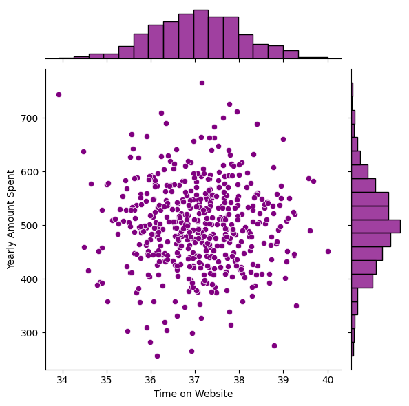

```python
jointplot = sns.jointplot(x='Time on Website', y='Yearly Amount Spent', data=dados, kind='scatter', color='purple')
```

Não há uma correlação clara entre o tempo gasto nos sites e o montante anual gasto. Uma correlação clara seria se ao aumentar o tempo gasto o gasto anual também aumentasse.

** Faça o mesmo, mas com a coluna tempo no aplicativo (Time on App), em vez disso. **

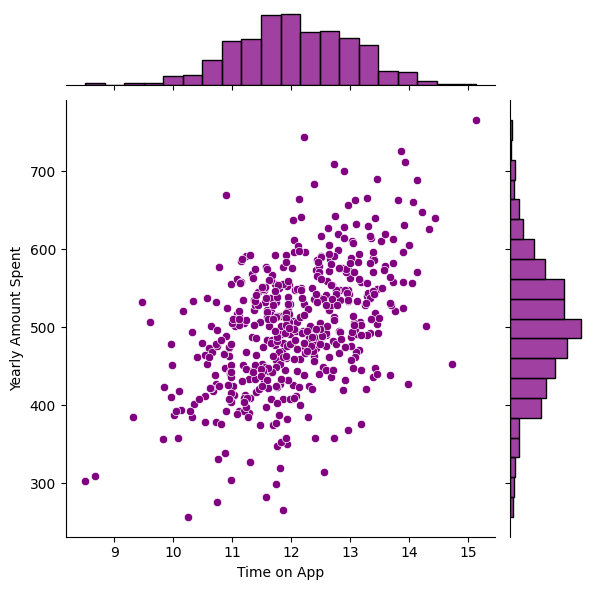

```python
jointplot2 = sns.jointplot(x='Time on App', y='Yearly Amount Spent', data=dados, kind='scatter', color='purple')
```

** Use jointplot criar um lote de caixa hexagonal 2D que compara tempo no aplicativo (Time on App) e o tempo da associação (Length of Membership). **

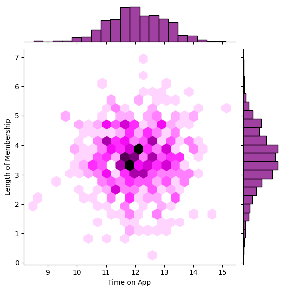

```python
jointplot2d = sns.jointplot(x='Time on App', y='Length of Membership', data=dados, kind='hex', color='purple')
```

** Vamos explorar esses tipos de relações em todo o conjunto de dados. Use [parplot](https://stanford.edu/~mwaskom/software/seaborn/tutorial/axis_grids.html#plotting-pairwise-relationships-with-pairgrid-and-pairplot) para recriar o gráfico abaixo. (Não se preocupe com as cores) **

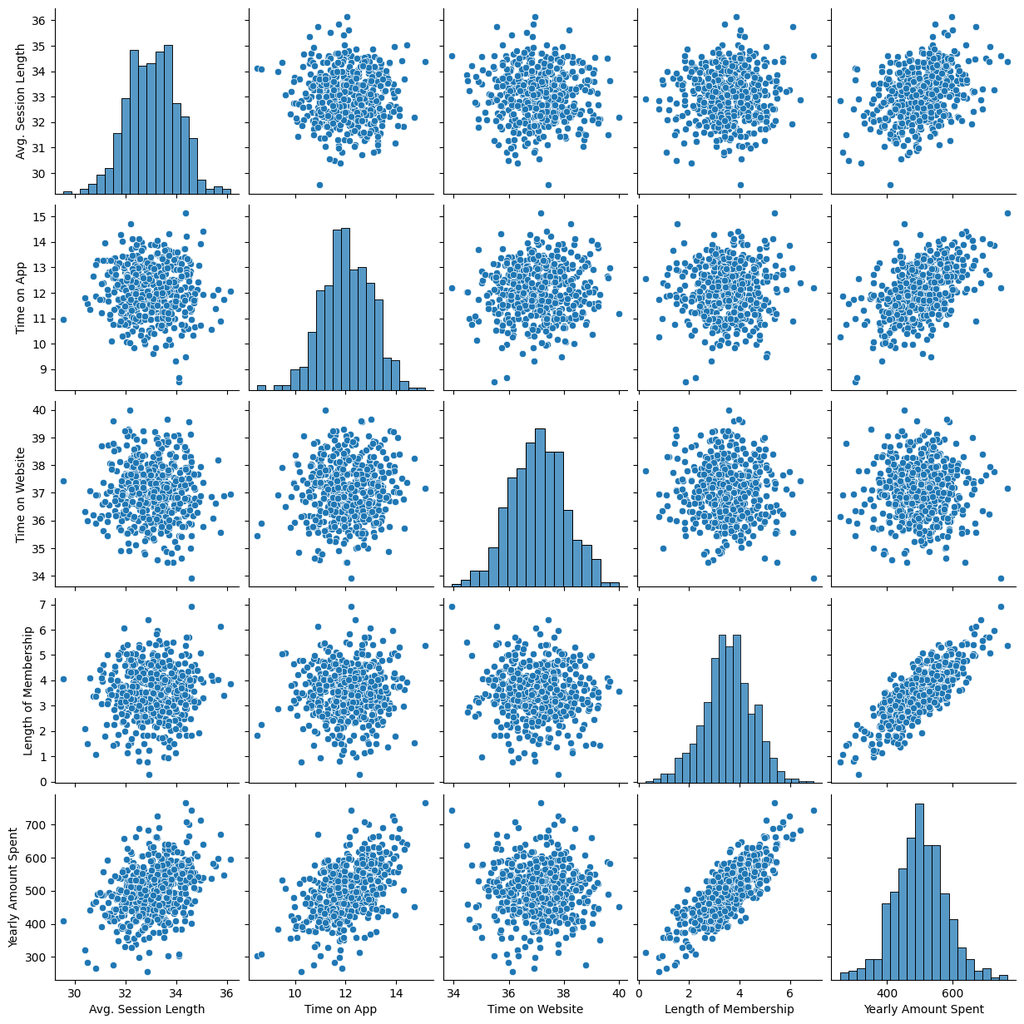

```python
parplot = sns.pairplot(dados)
```

** Baseado neste plot o que parece ser a característica mais correlacionada com o valor anual gasto (Yearly Amount Spent)? **

Aparente ser o tempo da associação/adesão, onde quanto mais tempo as pessoas passam sendo associadas mais elas gastam.

** Crie um plot de um modelo linear (usando o lmplot de Seaborn) da quantia anual gasta (Yearly Amount Spent) vs. tempo de associação (Length of Membership). **

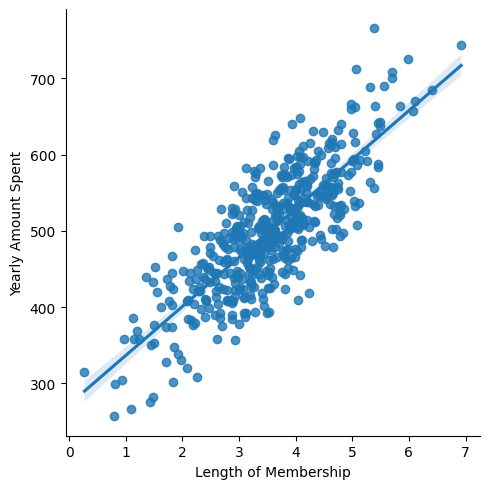

```python
linear = sns.lmplot(x='Length of Membership', y='Yearly Amount Spent', data=dados)
```

## Treinando e testando os dados

Agora que exploramos um pouco os dados, vamos avançar e dividir os dados em conjuntos de treinamento e teste. ** Defina uma variável X igual a todas as características numéricas dos clientes e uma variável y igual à coluna Valor anual gasto (Yearly Amount Spent). **

```python
X = dados[['Avg. Session Length', 'Time on App', 'Time on Website', 'Length of Membership']]
y = dados['Yearly Amount Spent']
```

** Use model_selection.train_test_split da sklearn para dividir os dados em conjuntos de treinamento e teste. Defina test_size = 0.3 e random_state = 101 **

```python
from sklearn.model_selection import train_test_split
```

```python
X_test, X_train, y_test, y_train = train_test_split(X, y, test_size=0.3, random_state=101)
```

## Treinando o modelo

Agora é hora de treinar nosso modelo em nossos dados de treinamento!

** Importe LinearRegression do sklearn.linear_model **

```python
from sklearn.linear_model import LinearRegression
```

** Crie uma instância de um modelo LinearRegression () chamado lm. **

```python
lm = LinearRegression()
```

** Treine lm nos dados de treinamento. **

```python
lm.fit(X_train, y_train)
```

```
LinearRegression()
```

**Print os coeficientes do modelo**

```python
print("Os coeficientes do modelo são:", lm.coef_)
```

```
Os coeficientes do modelo são: [25.11463945 39.0221878   0.76713598 62.24728656]
```

## Previsão de dados de teste

Agora que nos ajustamos ao nosso modelo, vamos avaliar o seu desempenho ao prever os valores de teste!

** Use lm.predict () para prever o conjunto X_test dos dados. **

```python
lm.predict(X_test)
```

[output not shown]

[output cut: 33 more lines]

[output not shown]

** Crie um diagrama de dispersão (scatterplot) dos valores reais de teste em relação aos valores preditos. **

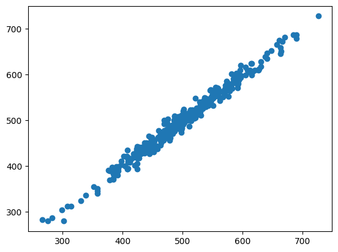

```python
dispersão = plt.scatter(y_test, lm.predict(X_test))
```

## Avaliando o Modelo

** Calcule o erro absoluto médio, o erro quadrado médio e o erro quadrado médio da raiz. Consulte a palestra ou a Wikipédia para as fórmulas **

```python
erro_absoluto_medio= np.mean(np.abs(y_test - lm.predict(X_test)))
erro_quadratico_medio = np.mean((y_test - lm.predict(X_test))**2)
erro_quadratico_medio_raiz = np.sqrt(erro_quadratico_medio)

print("Erro absoluto médio:", erro_absoluto_medio)
print("Erro quadrático médio:", erro_quadratico_medio)
print("Raiz do erro quadrático médio:", erro_quadratico_medio_raiz)
```

```
Erro absoluto médio: 8.27722410558531
Erro quadrático médio: 109.36337929836603
Raiz do erro quadrático médio: 10.457694741116038
```

## Resíduos

Você deve ter obtido um modelo muito bom com um bom ajuste. Vamos explorar rapidamente os resíduos para garantir que tudo esteja bem com os nossos dados.

** Trace um histograma dos resíduos e certifique-se de que ele parece normalmente distribuído. Use o seaborn distplot, ou apenas o plt.hist (). **

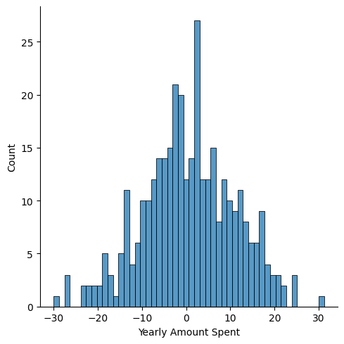

```python
residuos = sns.displot((y_test - lm.predict(X_test)), bins=50)
```

## Conclusão

Ainda desejamos descobrir a resposta à pergunta original, concentramos-nos no desenvolvimento de aplicativos móveis ou de sites? Ou talvez isso realmente não importe, e o tempo como membro é o que é realmente importante? Vamos ver se podemos interpretar os coeficientes para ter uma idéia.

** Recrie o quadro de dados abaixo. **

```python
coeficientes = pd.DataFrame(lm.coef_, X.columns, columns=['Coeficientes'])
print(coeficientes)
```

```
                      Coeficientes
Avg. Session Length      25.114639
Time on App              39.022188
Time on Website           0.767136
Length of Membership     62.247287
```

** Como você pode interpretar esses coeficientes? **

Os coeficientes mostram que para uma alteração de uma unidade de tempo, cada variável se altera em "coeficientes" unidades. Coeficientes mais altos tem maior impacto na regressão, mostrando onde o foco deve estar. Nesse caso o tempo no site tem pouco impacto, enquanto o tempo da associação tem maior impacto.

** Você acha que a empresa deve se concentrar mais em seu aplicativo móvel ou em seu site? **

De acordo com os coefientes, o foco deve ser no aplicativo móve, já que o seu coeficiente é, aproximadamente, 50 vezes maior.